# Mouse Ribo-seq Report

23 August 2021

The following document is a report on the alignment of multiple Ribo-Seq datasets against NMD and RI transcripts . These alignments are then analyzed in respect to their mapping against the previously determined unique Regions of the also previously determined split-ORFs.

## Alignment against NMD transcripts

The thresholds for each dataset are determined by calculating the average relative read count (number of reads per bp) aligning to randomly selected regions of the 3’UTR-regions of the longest isoforms of all coding transcripts.

Thresholds for each dataset

|  | Threshold |
| --- | --- |
| iPSc_01_vs_NMD | 0.0139836 |
| iPSc_02_vs_NMD | 0.1167258 |

Regions above the threshold

|  | Number of unique regions with relative count >= threshold |
| --- | --- |
| iPSc_01_vs_NMD | 4 |
| iPSc_02_vs_NMD | 4 |

### The following table shows the top five unique regions with a relative count above the threshold (if available).

iPSc_01_vs_NMD

| ID | start | stop | read_count | relative_count |
| --- | --- | --- | --- | --- |
| ENSMUSG00000032366\|ENSMUST00000129733:ORF-2213:54:528 | 217 | 240 | 5 | 0.217391 |
| ENSMUSG00000032366\|ENSMUST00000129733:ORF-2213:54:528 | 446 | 474 | 5 | 0.178571 |
| ENSMUSG00000032366\|ENSMUST00000139046:ORF-4567:133:682 | 258 | 330 | 10 | 0.138889 |
| ENSMUSG00000032366\|ENSMUST00000129733:ORF-2213:54:528 | 35 | 195 | 20 | 0.125000 |

iPSc_02_vs_NMD

| ID | start | stop | read_count | relative_count |
| --- | --- | --- | --- | --- |
| ENSMUSG00000032366\|ENSMUST00000129733:ORF-2213:54:528 | 217 | 240 | 5 | 0.217391 |
| ENSMUSG00000032366\|ENSMUST00000129733:ORF-2213:54:528 | 446 | 474 | 5 | 0.178571 |
| ENSMUSG00000032366\|ENSMUST00000139046:ORF-4567:133:682 | 258 | 330 | 10 | 0.138889 |
| ENSMUSG00000032366\|ENSMUST00000129733:ORF-2213:54:528 | 35 | 195 | 20 | 0.125000 |

### The following plot shows how many unique regions are expressed in which dataset and how those overlap with the other data sets.

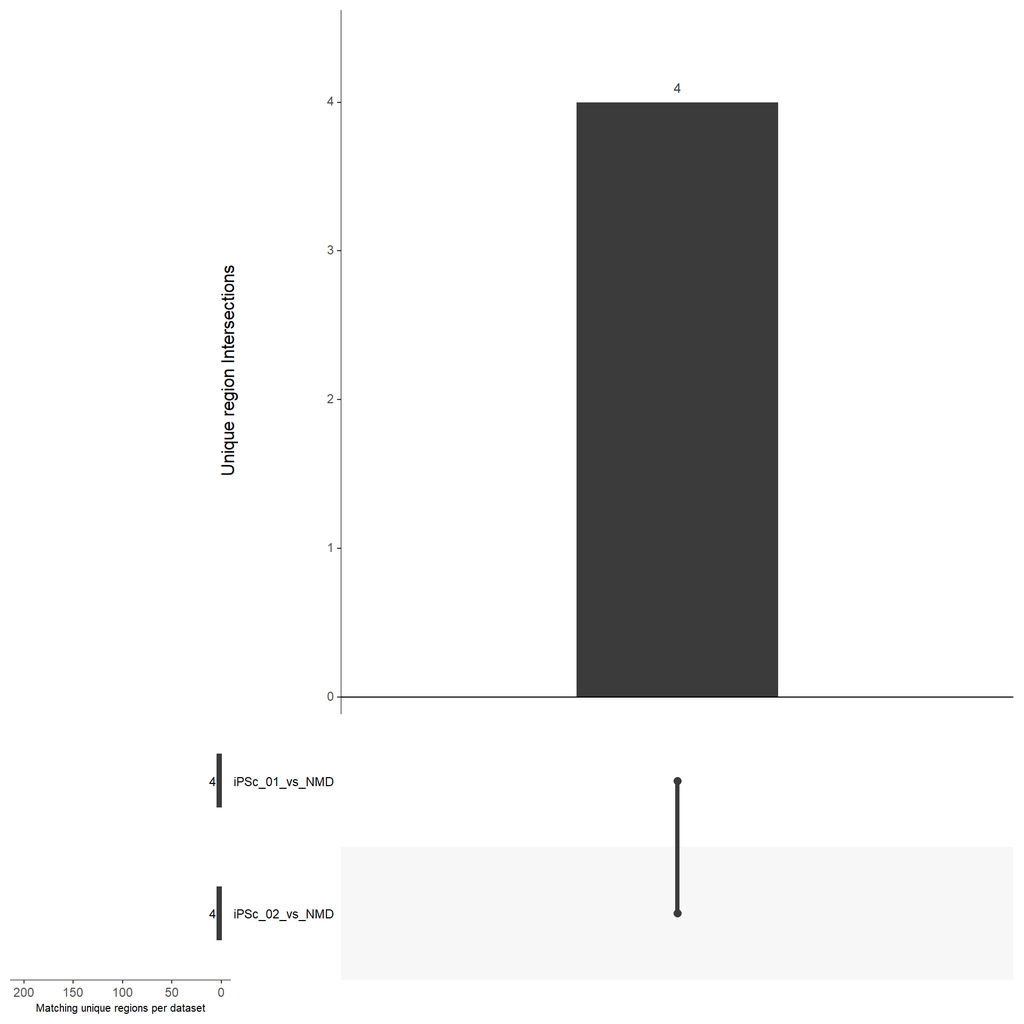

## Alignment against RI transcripts

The thresholds for each dataset are determined by calculating the average relative read count (number of reads per bp) aligning to randomly selected regions of the 3’UTR-regions of the longest isoforms of all coding transcripts.

Thresholds for each dataset

|  | Threshold |
| --- | --- |
| iPSc_01_vs_RI | 0.0017599 |
| iPSc_02_vs_RI | 0.0951317 |

Regions above the threshold

|  | Number of unique regions with relative count >= Threshold |
| --- | --- |
| iPSc_01_vs_RI | 2 |
| iPSc_02_vs_RI | 2 |

### The following table shows the top five unique regions with a relative count above the threshold (if available).

iPSc_01_vs_RI

| ID | start | stop | read_count | relative_count |
| --- | --- | --- | --- | --- |
| ENSMUSG00000024985\|ENSMUST00000111654:ORF-1021:458:1907 | 381 | 450 | 1940 | 28.115900 |
| ENSMUSG00000021012\|ENSMUST00000221558:ORF-27679:123:564 | 400 | 441 | 20 | 0.487805 |

iPSc_02_vs_RI

| ID | start | stop | read_count | relative_count |
| --- | --- | --- | --- | --- |
| ENSMUSG00000024985\|ENSMUST00000111654:ORF-1021:458:1907 | 381 | 450 | 1940 | 28.115900 |
| ENSMUSG00000021012\|ENSMUST00000221558:ORF-27679:123:564 | 400 | 441 | 20 | 0.487805 |

### The following plot shows how many unique regions are expressed in which dataset and how those overlap with the other data sets.

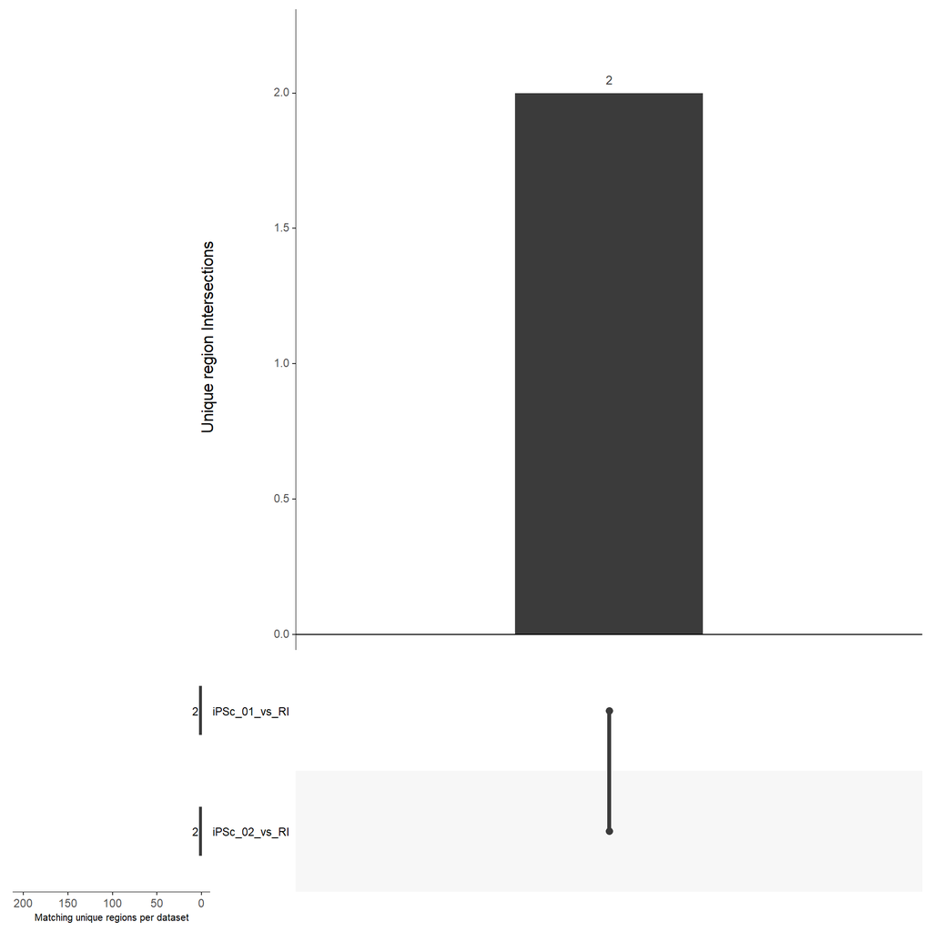